# Español 1.5: Capítulo 3

Middlebury College: Verano 2014

## Repaso

- Vocabulario
  - el hotel
  - los números
- Verbos irregulares
  - e > ie
  - e > i
  - o > ue
  - u > ue
  - verbos -go

Recordad…

- la bota
  - las formas nosotros y vosotros no tienen cambio de raíz
- verbos -go cambian en forma de yo
  - salir > salgo
- Actividad 2-28 p. 77
- Actividad 2-30 p. 77

## Puentes Capítulo 3 - “Entre familia”

## El plan

- Vocabulario:
  - preguntas para el juez Garzón
  - descripciones
- Gramática:
  - Los adjetivos
  - Los adjetivos comparativos
  - Los adjetivos superlativos
- Estrategias para la comunicación oral

## ¿Cómo son las personas?: las descripciones personales

[figure not shown]

- ¿Cómo son estas personas?
- Haz una lista de adjetivos útiles

## Vocabulario útil: los rasgos físicos

[figure not shown]

## Vocabulario útil: la personalidad y el carácter

[figure not shown]

## Los adjetivos: la concordancia de número y género

[figure not shown]

- Los adjetivos **concuerdan** con sus respectivos sustantivos en cuanto al **número** y al **género**
- *Dulce* es muy bonit**a**.
- Es simpátic**a** pero muy seri**a**.
- Es muy amable y trabajador**a**.
- Tiene *el pelo* castañ**o**.

## Los adjetivos: la concordancia de número y género

[figure not shown]

- Los adjetivos **concuerdan** con sus respectivos sustantivos en cuanto al **número** y al **género**
- *Carlos* es muy alt**o** y guap**o**.
- Es tímid**o** pero muy divertid**o**.
- Es muy responsable y optimista. (¡ojo aquí!)
- Tiene el pelo negr**o**.

## Más sobre los adjetivos

| Adjetivos | Masculino |  | Femenino |  |
| --- | --- | --- | --- | --- |
| termina en: | **Singluar** | **Plural** | **Singluar** | **Plural** |
| -o | alt**o** | alt**os** | alt**a** | alt**as** |
| -e | amabl**e** | amabl**es** | amabl**e** | amabl**es** |
| consonante | informa**l** | informa**les** | informa**l** | informa**les** |
| -dor | trabaja**dor** | trabaja**dores** | trabaja**dora** | trabaja**doras** |
| -ista | optim**ista** | optim**istas** | optim**ista** | optim**istas** |

## Descanso (10 minutos)

## Más sobre los adjetivos

- En general, ponemos los adjetivos **después** de los sustantivos
  - Tiene el *pelo* **negro** y los *ojos* **grandes** y **azules**.
- Algunos adjetivos **especiales** pueden aparecer **antes**.
  - Un **buen** *hombre*.
  - Un **mal** *ejemplo*.
  - Unos **buenos** *amigos*.

## Más sobre los adjetivos

- El adjetivo **grande** tiene dos significados que varían según su posición…
  - Una **gran** universidad.
  - Una universidad **grande**.
- Ejercicio 3-6, p. 94
- Ejercicio 3-8, p. 95

## Los comparativos y los superlativos

## Las comparaciones de superioridad:

*más* + (**adjetivo**, **adverbio**, **sustantivo**) + *que*

[figure not shown]

- Sultán es *más* **grande** *que* Preciosa.
- Sultán come *más* **rápidamente** *que* Preciosa.
- Sultán tiene *más* **energía** *que* Preciosa.

## Las comparaciones de inferioridad:

*menos* + (**adjetivo**, **adverbio**, **sustantivo**) + *que*

[figure not shown]

- Lobo es *menos* **grande** *que* Preciosa.
- Lobo duerme *menos* **tranquilamente** *que* Preciosa.
- Lobo tiene *menos* **juguetes** *que* Preciosa.

## Las comparaciones irregulares:

- Lobo es **menor** que Preciosa.
- Preciosa es **mayor** que Lobo.
- La personalidad de Preciosa es **mejor** que la personalidad de Lobo.
- La personalidad de Lobo es **peor** que la personalidad de Sultán.

## Las comparaciones de igualdad:

*tan* + (**adjetivo**, **adverbio**) + *como*

[figure not shown]

- Lobo es *tan* **malo** *como* Sultán.
- Lobo corre *tan* **rápidamente** *como* Sultán.

## Las comparaciones de igualdad:

*tanto(s), tanta(s)* + (**sustantivo**) + *como*

[figure not shown]

- Lobo tiene *tantos* **juguetes** *como* Sultán.
- Lobo tiene *tanta* **energía** *como* Sultán.
- ¡OJO! Lobo come **tanto como** Sultán.

## Los superlativos expresan los extremos

*el, la, los, las* + (**sustantivo**) + *más/menos* + (**adjetivo**) de un grupo

[figure not shown]

- Sultán es *el* **perro** *más* **grande** de los tres.
- Lobo es *el* *menos* **grande** pero *el* *más* **feroz** del grupo.

## Ejercicios

- 3-12

## Repaso

- Vocabulario:
  - descripciones
- Gramática:
  - Los adjetivos
  - Los adjetivos comparativos
  - Los adjetivos superlativos
- Estrategias para la comunicación oral

## Con un compañero…

- Actividad 2-29 p. 77
- Actividad 3-13 p. 98

## El plan

- Vocabulario:
  - La familia
- Gramática
  - Ser y estar
- Instrucciones Examen Oral 1
- Estrategias para la comunicación oral

## Repasito

[figure not shown]

[figure not shown]

## La familia

[figure not shown]

## Mi árbol genealógico

- En una hoja de papel dibujad una imagen de ti mismo.
- Debajo de la imagen, pon tu nombre.
- Intercambiar hojas con un vecino.
- Descríbele tu familia para que él/ella pueda rellenar tu árbol.
- Devuelve la hoja y haz las correcciones necesarias.
- Comparte con la clase la descripción del árbol

## Las mascotas

[figure not shown]

- ¿Cuántas mascotas tienes?
- ¿Qué tipos de mascotas hay en tu casa?

## Descanso (10 minutos)

## Ser y estar

## El verbo ser: para identificar y clasificar

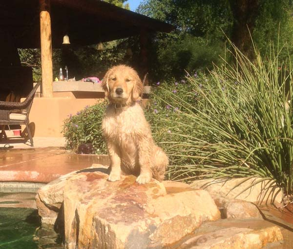

- Maya **es** mi perra.
- Mi hermana **es** enfermera.
- Yo **soy** lingüista.
- Tú **eres** estudiante.
- Jing **es** de Slytherin.

## El verbo ser: para describir características con los adjetivos

[figure not shown]

- Sultán **es** grande y feroz.
- Sultán y Lobo **son** buenos perros.

## Los usos del verbo ser: con la preposición "de"

[figure not shown]

- **Posesión**
  - ¿De quién **es** el cuarto? **Es** de Alicia.
- **Origen**
  - ¿De dónde **es** Manel? **Es** de España.

## Los usos del verbo ser: con la HORA y el LUGAR de los eventos

[figure not shown]

- ¿Cuándo **es** la fiesta?
- **Es** el sábado a las siete de la noche.
- La fiesta **es** en la casa del profesor.

## Los usos del verbo estar: la ubicación de las cosas

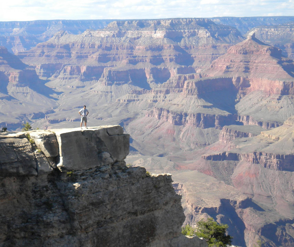

- ¿Dónde **está** el profe?
- **Está** en el gran cañón.

## Los usos del verbo estar: para describir una condición

[figure not shown]

- ¿Cómo **está** Jackie Chan?
- **Está**…

## Ser y estar: las características versus las condiciones

[figure not shown]

¿Cómo **es** Jackie Chan?

- **Es** bajo con pelo negro.
- **Es** simpático.

¿Cómo **está** Jackie Chan?

- **Está** confundido.
- **Está** frustrado.

## Ejercicios

- Actividad 3-24, p. 107
- Actividad 3-25, p. 108
- Actividad 3-26, p. 108

## Estrategias para la comunicación oral

- Con un compañero haz una lista de 4 o 5 cosas que puedes hacer para mejorar la comunicación oral.
- Piensa en estrategias que puedes practicar sólo, con otras personas, en casa, en clase, etc.

## Instrucciones Examen Oral 1

## Repaso

- Vocabulario:
  - La familia
- Gramática
  - Ser y estar
- Instrucciones Examen Oral 1
- Estrategias para la comunicación oral

## El plan

- Vocabulario:
  - Los muebles la casa
  - La rutina
- Gramática:
  - Reflexivos
  - El participio pasado
- Preparación Examen Oral 1: individual (capítulos 1, 2 y 3)

## ¿Dónde vive la familia?: la casa

[figure not shown]

## ¿Cómo es la casa?: describir características de la casa

[figure not shown]

- Mi casa es **nueva** (**vieja**).
- La sala es **grande** y **cómoda**.
- Los muebles son **elegantes**.

## ¿Cómo es la casa?: describir la casa, los cuartos y los muebles

[figure not shown]

- Normalmente, mi cuarto está **ordenado** (**desordenado**).
- Por lo general, la cocina está **limpia**.
- Por desgracia, el **refrigerador** está **descompuesto** y la **ventana** está **rota**.

## Las relaciones espaciales - ¿Dónde está el gato

[figure not shown]

## Ejercicios

- 3-21 p. 105 (audio)
- 3-22 p. 105

## Un día ajetreado: la rutina diaria

- Por la mañana…

[figure not shown]

## Un día ajetreado: la rutina diaria

- Por la mañana…

[figure not shown]

## Un día ajetreado: la rutina diaria

[figure not shown]

## Un día ajetreado: la rutina diaria

- Por la tarde…

[figure not shown]

## Un día ajetreado: la rutina diaria

- Por la noche…

[figure not shown]

## Ejercicios

- 3-29, p. 111 (audio)
- 3-30, p. 111

## Descanso (10 minutos)

## Los verbos reflexivos

## Los verbos reflexivos: el sujeto y el objeto son la misma persona

[figure not shown]

## Los pronombres reflexivos reflejan el sujeto de la frase

[figure not shown]

- Prefiero levantar**me** temprano.
- Me lavo **LOS** dientes todos los días.

## Los verbos regulares:

[figure not shown]

## Los verbos irregulares

[figure not shown]

## Ejercicios

- 3-33, p. 115
- 3-34, p. 115

## JT

[interactive chart not shown]

## Preparación Examen Oral 1: individual (capítulos 1, 2 y 3)

- Eres el/la profesor/a. Escoge dos o tres preguntas de cada capítulo y házselas a tu compañero (ver hoja de ayer)
- Presta atención al vocabulario que necesitas, que olvidas, etc.
- Apunta cuántas veces tu compañero tiene que pausar, pensar, etc. ¿Parece fluido?
- Proporciónale una nota a tu compañero y dale sugerencias para mejorar.

## Repaso

- Vocabulario:
  - Los muebles la casa
  - La rutina
- Gramática:
  - Reflexivos
  - El participio pasado
- Preparación Examen Oral 1: individual (capítulos 1,2 y 3)